# Tutorial 1: Introduction to Git, VSCode, and Data Exploration

CHEE4003: Special Topics A - Artificial Intelligence in Chemical Engineering

Published

October 8, 2026

# Introduction

Welcome to CHEE4003! In this tutorial, we will get setup with VSCode, Git, and practice some basic data exploration with UQ’s Distillation Pilot Plant.

## Visual Studio Code (VSCode)

VSCode is an **integrated development environment (IDE)** that provides a user-friendly interface for writing and managing code. Previously, you will have had experience with python-only IDE’s like IDLE, and Spyder. VSCode is significantly more powerful and flexible, allowing you to work with multiple programming languages and tools in one place.

As such, we highly recommend that you use VSCode for this course. It is free, open-source, and available for Windows, macOS, and Linux. You can download it from the [official website](https://code.visualstudio.com/).

One of the main reasons that we suggest using VSCode is its inline ability to work with **Git**

## Git

Git is a **version control system** that allows you to track changes in your code and collaborate with others. It is widely used in software development and data science projects. You can think of it like a “save” button for your code, but with the ability to go back to previous versions and see who made changes. It can be used both by solo developers and teams, making it a versatile tool for managing codebases.

| Term | Definition |
| --- | --- |
| **Committing** | Saving a snapshot of your changes in the local Git repository. |
| **Pushing** | Sending your committed changes from your local repository to a remote repository (the cloud). |
| **Pulling** | Downloading and integrating changes from a remote repository into your local repository. |

### Installing Git

To get started with Git, you will need to install it on your computer. You can download it from the [official website](https://git-scm.com/).

**ImportantREAD IF USING MAC**

If you are using a Mac, you will also need to have homebrew installed. Homebrew is a package manager for macOS that makes it easy to install and manage software. You can install Homebrew by following the instructions on the [official website](https://brew.sh/). Once you have Homebrew installed, you can use it to install Git by running the following command in your terminal:

```bash
brew install git
```

**ImportantREAD IF USING WINDOWS**

If you are using Windows, you can download the Git installer from the [official website](https://git-scm.com/). Run the installer and follow the prompts to complete the installation. You do not need to adjust any settings during the installation process; just click “Next” (or select the recommended options) until the installation is complete.

Once Git is installed, you can verify the installation by opening a terminal (or command prompt) and typing the following command:

```bash
git --version
```

Afterwards, you will need to configure Git with your name and email address. This information will be associated with your commits and is important for collaboration. You can set your name and email by running the following commands in your terminal:

```bash
git config --global user.name "Your Name"
```

```bash
git config --global user.email "your.email@example.com"
```

**Note**

You do not **need** to use git for this course, but it is highly recommended. Learning Git will save a lot of headaches in the future, especially when working on larger projects or collaborating with others. It is a valuable skill that is widely used in the industry.

### Using Git in VSCode

VSCode has built-in support for Git, making it easy to manage your code and track changes. You can access Git features directly from the VSCode interface, allowing you to commit changes, view the history of your code, and collaborate with others without leaving the editor.

To start using Git for a project you can follow these steps:

1. Open VSCode and navigate to the folder where your project is located.
2. Click on the branch icon in the left sidebar to open the Source Control panel, and then click on the “Initialize Repository” button to create a new Git repository for your project. See Figure 1 below:

[figure not shown]

Figure 1: Initialising a Git repository in VSCode.

Once you have initialised a Git repository, it will automatically start tracking changes in your project. When you make changes to your code, you will see the changes listed in the source control panel. You can then choose to either: commit all your changes, or select specific files to commit. Additionally, you can (and should!) add a commit message to describe the changes you have made.

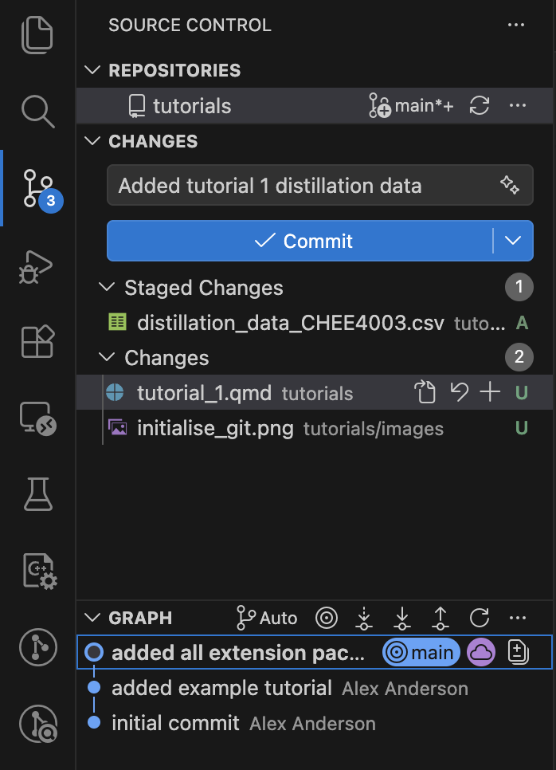

Figure 2: Git changes in VSCode.

As shown in Figure 2, you can see that one file has been staged for commit, and the other two have not. A useful commit message has also been added. Commit messages are important for documenting the changes you have made, and they should be clear and concise. A good commit message should describe what changes were made and why they were made.

In this course, you will not be collaborating with other students, hence you will not need to push your changes to a remote repository. As such, you will not have to worry about pulling changes or pushing changes.

**Caution**

If you do decide to use Github as a cloud repository, you will have to make sure to set your remote repository as **private**. If you are found to have a public repository containing assessment code, you will be in breach of the UQ Academic Integrity Policy.

## Exploring the UQ Distillation Dataset

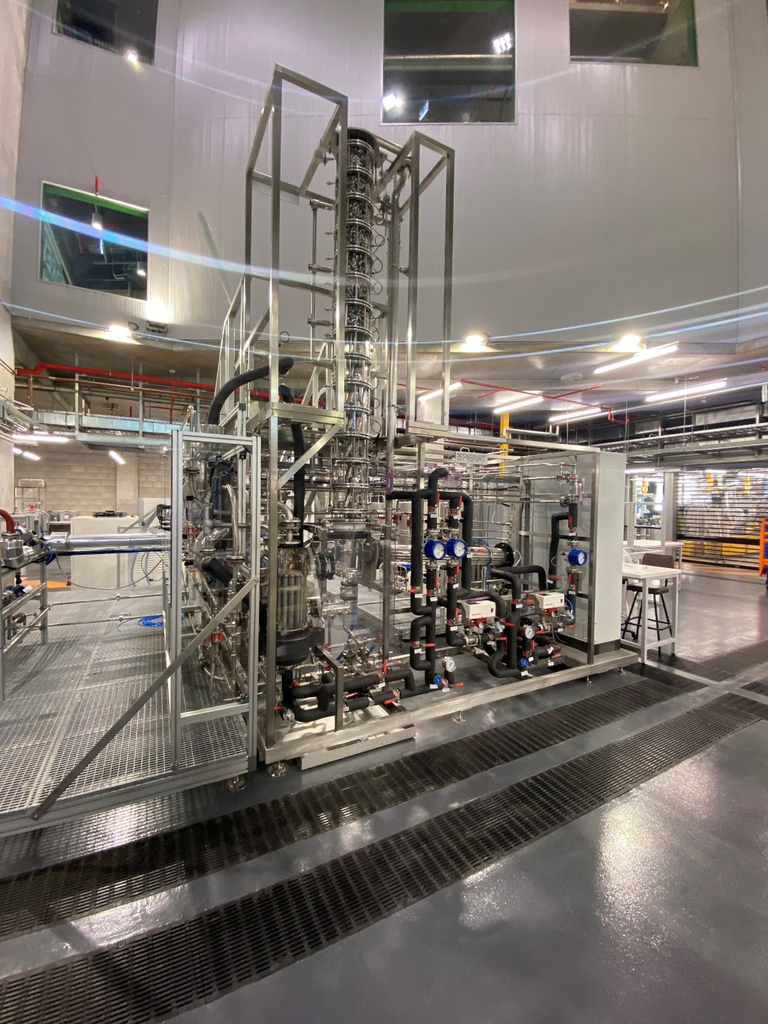

Figure 3: Photograph of the PIGNAT Pilot Distillation Plant. The unit contains a reboiler, distillation column, condenser, and associated control instrumentation.

During operation, a mixture of ethylene glycol and water is fed to the distillation column, where heat supplied to the reboiler generates vapour that rises through the column and contacts the descending liquid phase. This counter-current interaction promotes mass transfer between the vapour and liquid streams, enabling separation based on differences in volatility. As the vapour rises, the more volatile water preferentially moves towards the top of the column, while the less volatile ethylene glycol becomes concentrated in the liquid flowing towards the bottom.

To monitor the process, the plant is equipped with a wide range of temperature, pressure, flow, and level sensors located throughout the distillation column, reboiler, condenser, feed system, and product streams. The recorded variables include tray, boiler, condenser, and product temperatures; feed, reflux, distillate, steam, and cooling-water flow rates; liquid levels; and operating pressures. These measurements are continuously recorded over time and provide valuable information about the performance and stability of the distillation process.

The **UQ Distillation Dataset** contains operational data collected during several runs of the pilot plant and provides a realistic example of industrial process data.

You can download the dataset here:

```
CHEE4003_distillation_data.csv
```

```
"Time,s",Boiler_Temperature,Column_Bottom_Tray_1,Column_Bottom_Tray_2,Column_Bottom_Tray_3,Column_Bottom_Tray_4,Column_Bottom_Tray_5,Column_Bottom_Tray_6,Column_Bottom_Tray_7,Column_Bottom_Tray_8,Column_Top_Tray_9,Column_Top_Tray_10,Column_Top_Tray_11,Column_Top_Tray_13,Column_Top_Tray_14,Column_Top_Tray_15,Column_Head_Temperature,Distillate_Temperature,Reflux_Temperature,Distillate_to_TK02_Temperature,Bottom_to_TK03_Temperature,Water_E01_Inlet_Temperature,Water_E01_Outlet_Temperature,Steam_B01_Inlet_Temperature,Steam_B01_Outlet_Temperature,Feed_Preheating_Temperature_Control,Condenser_E01_Vent_Temperature,Feed_Flow_Control,Reflux_Flow_Control,Bottom_Product_Flow,Distillate_Flow,Heating_Steam_Inlet_Flow,Water_E01_Flow_Control,Boiler_Level_Control,Distillate_Level_Control,Feed_Tank_Level,Bottom_Product_Tank_Level,Distillate_Product_Tank_Level,Column_Differential_Pressure,Steam_Pressure_Control,Vacuum_Nitrogen_Pressure_Control
0,25.218629837036133,26.255769729614258,24.771589279174805,27.441919326782227,24.288789749145508,24.90273094177246,26.273649215698242,25.802770614624023,25.50473976135254,27.77570915222168,26.565719604492188,26.738569259643555,26.822019577026367,24.884849548339844,26.47631072998047,25.701440811157227,25.37957000732422,27.579010009765625,23.56159019470215,20.88530921936035,17.672569274902344,19.12693977355957,26.243850708007812,25.337839126586914,27.22138023376465,24.461639404296875,0.1458009034395218,0.017427029088139534,0.017296580597758293,-0.0176237802952528,-0.03147102892398834,2510.68603515625,90.24041748046875,33.270389556884766,92.9903793334961,13.64346981048584,11.23779010772705,1.3385030031204224,0.030375080183148384,890.1464233398438
10,25.224590301513672,25.99350929260254,24.676219940185547,27.263099670410156,24.109970092773438,24.729869842529297,26.184240341186523,25.617990493774414,25.486860275268555,27.78166961669922,26.571680068969727,26.738569259643555,26.798179626464844,24.801389694213867,26.386899948120117,25.701440811157227,25.37957000732422,27.579010009765625,23.56159019470215,20.88530921936035,17.481830596923828,18.93621063232422,26.24980926513672,25.337839126586914,27.22138023376465,24.175540924072266,0.1458009034395218,0.01831435039639473,0.01941061019897461,-0.018577469512820244,-0.02431836910545826,2528.424072265625,90.32147979736328,33.58034133911133,92.99514770507812,13.64346981048584,11.23779010772705,1.2955869436264038,0.030375080183148384,833.6691284179688
20,25.224590301513672,25.892179489135742,24.586820602416992,27.137929916381836,24.020570755004883,24.723909378051758,25.99350929260254,25.522619247436523,25.486860275268555,27.68630027770996,26.565719604492188,26.696849822998047,26.798179626464844,24.795429229736328,26.380939483642578,25.701440811157227,25.385530471801758,27.573049545288086,23.55562973022461,20.88530921936035,17.386459350585938,18.840839385986328,26.237890243530273,25.337839126586914,27.227340698242188,23.97287940979004,0.1458009034395218,0.017185160890221596,0.017185330390930176,-0.016670089215040207,-0.01358937006443739,2545.162109375,90.34294128417969,33.926048278808594,92.9903793334961,13.64346981048584,11.23779010772705,1.2312129735946655,0.028944550082087517,780.7393188476562
30,25.218629837036133,25.701440811157227,24.586820602416992,27.072370529174805,23.925199508666992,24.6285400390625,25.916019439697266,25.433210372924805,25.486860275268555,27.68630027770996,26.565719604492188,26.649169921875,26.798179626464844,24.795429229736328,26.386899948120117,25.612030029296875,25.37957000732422,27.573049545288086,23.55562973022461,20.88530921936035,17.291099548339844,18.662029266357422,26.237890243530273,25.337839126586914,27.22138023376465,23.865589141845703,0.1458009034395218,0.01742566004395485,0.017296340316534042,-0.017578259110450745,-0.029682869091629982,2544.302978515625,90.37870788574219,34.25983810424805,92.99276733398438,13.64346981048584,11.23779010772705,1.1191550493240356,0.02918297052383423,731.0997924804688
... (8563 more lines)
```

Now that you have the dataset, we will use **Python** to explore it. This is a core skill in data-driven chemical engineering: before you can model, optimise, or control a process, you must first understand the data it produces. Over the following tasks you will load, clean, visualise, and statistically analyse real operational data from the UQ pilot distillation column.

**NoteLearning Objectives**

By the end of this section you will be able to:

1. **Load and inspect** chemical process data using Python
2. **Clean and preprocess** data for analysis
3. **Visualise** process variables and their relationships
4. **Identify patterns** and draw engineering insight from process data

### Task 1 : Setting up and loading the data

Create a new Python script (e.g. `data_exploration.py`) in your project folder, alongside the `CHEE4003_distillation_data.csv` file you downloaded above. The first thing any data analysis script does is import the necessary libraries. Add the following lines to the top of your script:

```python
import pandas as pd
import numpy as np
import matplotlib.pyplot as plt
import seaborn as sns
```

Next, write a function `load_data` that loads the dataset from the CSV file into a pandas **DataFrame** using `pd.read_csv`.

```
load_data.py
```

```python
def load_data(file_path):
    """
    Load the distillation data from a CSV file.

    Parameters
    ----------
    file_path : str
        The path to the CSV file.

    Returns
    -------
    df : pd.DataFrame
        A DataFrame containing the distillation data.
    """

    return df
```

distillation = load_data('data/CHEE4003_distillation_data.csv')

print(f"Dataset contains {distillation.shape[0]} time points and "

f"{distillation.shape[1]} variables")

Dataset contains 8566 time points and 41 variables

**Callout-answer**Answer**

```
load_data.py
```

```python
def load_data(file_path):
    """
    Load the distillation data from a CSV file.

    Parameters
    ----------
    file_path : str
        The path to the CSV file.

    Returns
    -------
    df : pd.DataFrame
        A DataFrame containing the distillation data.
    """
    df = pd.read_csv(file_path)
    return df

distillation = load_data('data/CHEE4003_distillation_data.csv')
print(f"Dataset contains {distillation.shape[0]} time points and "
      f"{distillation.shape[1]} variables")
```

Output

```
Dataset contains 8566 time points and 41 variables
```

### Task 2 : Inspecting the data

Write a function called `inspect_data` that starts by displaying the first few rows with `.head()` and listing the column names. Additionally, also use `.describe()` to get a statistical summary of the numeric variables. Finally, use `.info()` to check the data types and non-null counts.

```
inspect_data.py
```

```python
def inspect_data(df):
    """
    Perform an initial inspection of the dataset.

    Parameters
    ----------
    df : pd.DataFrame
        The dataset to inspect.

    Returns
    -------
    None
        Displays information about the dataset, including:
        - The first five rows
        - Column names
        - Summary statistics for numeric variables
        - Data types and non-null counts
    """
```

This will help you understand the structure and content of the dataset.

inspect_data(distillation)

First 5 rows:

Time,s Boiler_Temperature Column_Bottom_Tray_1 Column_Bottom_Tray_2 \

0 0 25.21863 26.255770 24.771589

1 10 25.22459 25.993509 24.676220

2 20 25.22459 25.892179 24.586821

3 30 25.21863 25.701441 24.586821

4 40 25.22459 25.707399 24.497400

Column_Bottom_Tray_3 Column_Bottom_Tray_4 Column_Bottom_Tray_5 \

0 27.441919 24.288790 24.902731

1 27.263100 24.109970 24.729870

2 27.137930 24.020571 24.723909

3 27.072371 23.925200 24.628540

4 26.982950 23.829821 24.539129

Column_Bottom_Tray_6 Column_Bottom_Tray_7 Column_Bottom_Tray_8 ... \

0 26.273649 25.802771 25.504740 ...

1 26.184240 25.617990 25.486860 ...

2 25.993509 25.522619 25.486860 ...

3 25.916019 25.433210 25.486860 ...

4 25.910061 25.433210 25.391491 ...

Heating_Steam_Inlet_Flow Water_E01_Flow_Control Boiler_Level_Control \

0 -0.031471 2510.686035 90.240417

1 -0.024318 2528.424072 90.321480

2 -0.013589 2545.162109 90.342941

3 -0.029683 2544.302979 90.378708

4 -0.013589 2534.503906 90.452606

Distillate_Level_Control Feed_Tank_Level Bottom_Product_Tank_Level \

0 33.270390 92.990379 13.64347

1 33.580341 92.995148 13.64347

2 33.926048 92.990379 13.64347

3 34.259838 92.992767 13.64347

4 34.605549 92.987999 13.64347

Distillate_Product_Tank_Level Column_Differential_Pressure \

0 11.23779 1.338503

1 11.23779 1.295587

2 11.23779 1.231213

3 11.23779 1.119155

4 11.23779 1.100081

Steam_Pressure_Control Vacuum_Nitrogen_Pressure_Control

0 0.030375 890.146423

1 0.030375 833.669128

2 0.028945 780.739319

3 0.029183 731.099792

4 0.032521 684.407227

[5 rows x 41 columns]

Column names:

Index(['Time,s', 'Boiler_Temperature', 'Column_Bottom_Tray_1',

'Column_Bottom_Tray_2', 'Column_Bottom_Tray_3', 'Column_Bottom_Tray_4',

'Column_Bottom_Tray_5', 'Column_Bottom_Tray_6', 'Column_Bottom_Tray_7',

'Column_Bottom_Tray_8', 'Column_Top_Tray_9', 'Column_Top_Tray_10',

'Column_Top_Tray_11', 'Column_Top_Tray_13', 'Column_Top_Tray_14',

'Column_Top_Tray_15', 'Column_Head_Temperature',

'Distillate_Temperature', 'Reflux_Temperature',

'Distillate_to_TK02_Temperature', 'Bottom_to_TK03_Temperature',

'Water_E01_Inlet_Temperature', 'Water_E01_Outlet_Temperature',

'Steam_B01_Inlet_Temperature', 'Steam_B01_Outlet_Temperature',

'Feed_Preheating_Temperature_Control', 'Condenser_E01_Vent_Temperature',

'Feed_Flow_Control', 'Reflux_Flow_Control', 'Bottom_Product_Flow',

'Distillate_Flow', 'Heating_Steam_Inlet_Flow', 'Water_E01_Flow_Control',

'Boiler_Level_Control', 'Distillate_Level_Control', 'Feed_Tank_Level',

'Bottom_Product_Tank_Level', 'Distillate_Product_Tank_Level',

'Column_Differential_Pressure', 'Steam_Pressure_Control',

'Vacuum_Nitrogen_Pressure_Control'],

dtype='str')

Statistical summary:

Time,s Boiler_Temperature Column_Bottom_Tray_1 \

count 8566.00 8562.00 8562.00

mean 42825.00 55.76 52.00

std 24729.36 40.54 40.35

min 0.00 24.85 25.61

25% 21412.50 27.14 26.45

50% 42825.00 33.36 28.84

75% 64237.50 70.40 56.97

max 85650.00 143.77 137.68

Column_Bottom_Tray_2 Column_Bottom_Tray_3 Column_Bottom_Tray_4 \

count 8562.00 8562.00 8562.00

mean 47.46 47.22 40.51

std 36.05 32.08 26.68

min 24.40 26.70 23.74

25% 24.96 27.35 24.36

50% 26.54 28.83 25.67

75% 53.87 53.87 48.10

max 133.49 135.68 130.85

Column_Bottom_Tray_5 Column_Bottom_Tray_6 Column_Bottom_Tray_7 \

count 8562.00 8562.00 8562.00

mean 37.80 36.75 34.81

std 20.98 16.81 14.65

min 24.45 25.82 25.33

25% 25.05 26.35 25.70

50% 26.28 27.39 26.54

75% 45.17 42.50 38.31

max 129.74 123.24 92.94

Column_Bottom_Tray_8 ... Heating_Steam_Inlet_Flow \

count 8562.00 ... 8562.00

mean 31.34 ... 3.27

std 9.87 ... 7.71

min 24.36 ... -2.35

25% 24.74 ... -0.02

50% 25.58 ... -0.01

75% 35.00 ... -0.00

max 62.00 ... 32.88

Water_E01_Flow_Control Boiler_Level_Control Distillate_Level_Control \

count 8562.00 8562.00 8562.00

mean 491.81 85.17 64.74

std 1008.55 2.17 14.25

min -9.63 68.35 27.76

25% -9.41 84.75 71.68

50% -9.34 86.06 71.72

75% -9.27 86.40 71.76

max 2657.82 99.28 71.81

Feed_Tank_Level Bottom_Product_Tank_Level \

count 8562.00 8562.00

mean 64.92 22.64

std 10.00 3.08

min 60.82 13.64

25% 60.92 23.88

50% 60.93 23.91

75% 60.94 23.91

max 100.98 23.92

Distillate_Product_Tank_Level Column_Differential_Pressure \

count 8562.00 8562.00

mean 27.85 1.69

std 5.75 4.18

min 11.18 -1.24

25% 30.29 -0.04

50% 30.29 -0.04

75% 30.30 -0.03

max 30.36 31.14

Steam_Pressure_Control Vacuum_Nitrogen_Pressure_Control

count 8562.00 8562.00

mean 0.62 823.25

std 1.61 369.14

min -0.22 91.39

25% -0.18 1010.80

50% -0.18 1020.98

75% -0.12 1022.10

max 4.63 1022.56

[8 rows x 41 columns]

Data types and non-null counts:

<class 'pandas.DataFrame'>

RangeIndex: 8566 entries, 0 to 8565

Data columns (total 41 columns):

# Column Non-Null Count Dtype

--- ------ -------------- -----

0 Time,s 8566 non-null int64

1 Boiler_Temperature 8562 non-null float64

2 Column_Bottom_Tray_1 8562 non-null float64

3 Column_Bottom_Tray_2 8562 non-null float64

4 Column_Bottom_Tray_3 8562 non-null float64

5 Column_Bottom_Tray_4 8562 non-null float64

6 Column_Bottom_Tray_5 8562 non-null float64

7 Column_Bottom_Tray_6 8562 non-null float64

8 Column_Bottom_Tray_7 8562 non-null float64

9 Column_Bottom_Tray_8 8562 non-null float64

10 Column_Top_Tray_9 8562 non-null float64

11 Column_Top_Tray_10 8562 non-null float64

12 Column_Top_Tray_11 8562 non-null float64

13 Column_Top_Tray_13 8562 non-null float64

14 Column_Top_Tray_14 8562 non-null float64

15 Column_Top_Tray_15 8562 non-null float64

16 Column_Head_Temperature 8562 non-null float64

17 Distillate_Temperature 8562 non-null float64

18 Reflux_Temperature 8562 non-null float64

19 Distillate_to_TK02_Temperature 8562 non-null float64

20 Bottom_to_TK03_Temperature 8562 non-null float64

21 Water_E01_Inlet_Temperature 8562 non-null float64

22 Water_E01_Outlet_Temperature 8562 non-null float64

23 Steam_B01_Inlet_Temperature 8562 non-null float64

24 Steam_B01_Outlet_Temperature 8562 non-null float64

25 Feed_Preheating_Temperature_Control 8562 non-null float64

26 Condenser_E01_Vent_Temperature 8562 non-null float64

27 Feed_Flow_Control 8562 non-null float64

28 Reflux_Flow_Control 8562 non-null float64

29 Bottom_Product_Flow 8562 non-null float64

30 Distillate_Flow 8562 non-null float64

31 Heating_Steam_Inlet_Flow 8562 non-null float64

32 Water_E01_Flow_Control 8562 non-null float64

33 Boiler_Level_Control 8562 non-null float64

34 Distillate_Level_Control 8562 non-null float64

35 Feed_Tank_Level 8562 non-null float64

36 Bottom_Product_Tank_Level 8562 non-null float64

37 Distillate_Product_Tank_Level 8562 non-null float64

38 Column_Differential_Pressure 8562 non-null float64

39 Steam_Pressure_Control 8562 non-null float64

40 Vacuum_Nitrogen_Pressure_Control 8562 non-null float64

dtypes: float64(40), int64(1)

memory usage: 2.7 MB

None

**Callout-answer**Answer**

```
inspect_data.py
```

```python
def inspect_data(df):
    """
    Perform an initial inspection of the dataset.

    Parameters
    ----------
    df : pd.DataFrame
        The dataset to inspect.

    Returns
    -------
    None
        Displays information about the dataset, including:
        - The first five rows
        - Column names
        - Summary statistics for numeric variables
        - Data types and non-null counts
    """

    # Display the first 5 rows to understand the data structure
    print("First 5 rows:")
    print(df.head())

    # List all of the process variables (columns) in the dataset
    print("Column names:")
    print(df.columns)

    # Provide a statistical summary of the numeric variables
    print("Statistical summary:")
    print(df.describe().round(2))

    # Check data types and non-null counts
    print("Data types and non-null counts:")
    print(df.info())

inspect_data(distillation)
```

Output

```
First 5 rows:
   Time,s  Boiler_Temperature  Column_Bottom_Tray_1  Column_Bottom_Tray_2  \
0       0            25.21863             26.255770             24.771589
1      10            25.22459             25.993509             24.676220
2      20            25.22459             25.892179             24.586821
3      30            25.21863             25.701441             24.586821
4      40            25.22459             25.707399             24.497400

   Column_Bottom_Tray_3  Column_Bottom_Tray_4  Column_Bottom_Tray_5  \
0             27.441919             24.288790             24.902731
1             27.263100             24.109970             24.729870
2             27.137930             24.020571             24.723909
3             27.072371             23.925200             24.628540
4             26.982950             23.829821             24.539129

   Column_Bottom_Tray_6  Column_Bottom_Tray_7  Column_Bottom_Tray_8  ...  \
0             26.273649             25.802771             25.504740  ...
1             26.184240             25.617990             25.486860  ...
2             25.993509             25.522619             25.486860  ...
3             25.916019             25.433210             25.486860  ...
4             25.910061             25.433210             25.391491  ...

   Heating_Steam_Inlet_Flow  Water_E01_Flow_Control  Boiler_Level_Control  \
0                 -0.031471             2510.686035             90.240417
1                 -0.024318             2528.424072             90.321480
2                 -0.013589             2545.162109             90.342941
3                 -0.029683             2544.302979             90.378708
4                 -0.013589             2534.503906             90.452606

   Distillate_Level_Control  Feed_Tank_Level  Bottom_Product_Tank_Level  \
0                 33.270390        92.990379                   13.64347
1                 33.580341        92.995148                   13.64347
2                 33.926048        92.990379                   13.64347
3                 34.259838        92.992767                   13.64347
4                 34.605549        92.987999                   13.64347

   Distillate_Product_Tank_Level  Column_Differential_Pressure  \
0                       11.23779                      1.338503
1                       11.23779                      1.295587
2                       11.23779                      1.231213
```

[output cut: 147 more lines]

```
 29  Bottom_Product_Flow                  8562 non-null   float64
 30  Distillate_Flow                      8562 non-null   float64
 31  Heating_Steam_Inlet_Flow             8562 non-null   float64
 32  Water_E01_Flow_Control               8562 non-null   float64
 33  Boiler_Level_Control                 8562 non-null   float64
 34  Distillate_Level_Control             8562 non-null   float64
 35  Feed_Tank_Level                      8562 non-null   float64
 36  Bottom_Product_Tank_Level            8562 non-null   float64
 37  Distillate_Product_Tank_Level        8562 non-null   float64
 38  Column_Differential_Pressure         8562 non-null   float64
 39  Steam_Pressure_Control               8562 non-null   float64
 40  Vacuum_Nitrogen_Pressure_Control     8562 non-null   float64
dtypes: float64(40), int64(1)
memory usage: 2.7 MB
None
```

**Tip**

Compare these variable names against the process control diagram (PCD) of the distillation column so that you understand what each one physically represents. You will notice the variables group naturally into temperatures, flows, levels, and pressures.

### Task 3 : Determining missing values

Real sensor data is rarely perfect. Before analysing it, you must check for **missing values** (gaps where a sensor did not report a reading) and decide how to handle them. Write a function `count_missing_values` that uses `.isnull().sum()` to count missing values per column.

```
count_missing_values.py
```

```python
def count_missing_values(df):
    """
    Count the number of missing values in each column of the DataFrame.

    Parameters
    ----------
    df : pd.DataFrame
        The DataFrame to check for missing values.

    Returns
    -------
    None
        Prints the total number of missing values and the count per column.
    """
```

count_missing_values(distillation)

Total missing values: 160

Columns with missing values:

Boiler_Temperature 4

Column_Bottom_Tray_1 4

Column_Bottom_Tray_2 4

Column_Bottom_Tray_3 4

Column_Bottom_Tray_4 4

Column_Bottom_Tray_5 4

Column_Bottom_Tray_6 4

Column_Bottom_Tray_7 4

Column_Bottom_Tray_8 4

Column_Top_Tray_9 4

Column_Top_Tray_10 4

Column_Top_Tray_11 4

Column_Top_Tray_13 4

Column_Top_Tray_14 4

Column_Top_Tray_15 4

Column_Head_Temperature 4

Distillate_Temperature 4

Reflux_Temperature 4

Distillate_to_TK02_Temperature 4

Bottom_to_TK03_Temperature 4

Water_E01_Inlet_Temperature 4

Water_E01_Outlet_Temperature 4

Steam_B01_Inlet_Temperature 4

Steam_B01_Outlet_Temperature 4

Feed_Preheating_Temperature_Control 4

Condenser_E01_Vent_Temperature 4

Feed_Flow_Control 4

Reflux_Flow_Control 4

Bottom_Product_Flow 4

Distillate_Flow 4

Heating_Steam_Inlet_Flow 4

Water_E01_Flow_Control 4

Boiler_Level_Control 4

Distillate_Level_Control 4

Feed_Tank_Level 4

Bottom_Product_Tank_Level 4

Distillate_Product_Tank_Level 4

Column_Differential_Pressure 4

Steam_Pressure_Control 4

Vacuum_Nitrogen_Pressure_Control 4

dtype: int64

**Callout-answer**Answer**

```
count_missing_values.py
```

```python
def count_missing_values(df):
    """
    Count the number of missing values in each column of the DataFrame.

    Parameters
    ----------
    df : pd.DataFrame
        The DataFrame to check for missing values.

    Returns
    -------
    None
        Prints the total number of missing values and the count per column.
    """
    # Count missing values per column, and the total
    missing_counts = df.isnull().sum()
    total_missing = missing_counts.sum()

    print(f"Total missing values: {total_missing}")
    print("Columns with missing values:")
    print(missing_counts[missing_counts > 0])

count_missing_values(distillation)
```

Output

```
Total missing values: 160
Columns with missing values:
Boiler_Temperature                     4
Column_Bottom_Tray_1                   4
Column_Bottom_Tray_2                   4
Column_Bottom_Tray_3                   4
Column_Bottom_Tray_4                   4
Column_Bottom_Tray_5                   4
Column_Bottom_Tray_6                   4
Column_Bottom_Tray_7                   4
Column_Bottom_Tray_8                   4
Column_Top_Tray_9                      4
Column_Top_Tray_10                     4
Column_Top_Tray_11                     4
Column_Top_Tray_13                     4
Column_Top_Tray_14                     4
Column_Top_Tray_15                     4
Column_Head_Temperature                4
Distillate_Temperature                 4
Reflux_Temperature                     4
Distillate_to_TK02_Temperature         4
Bottom_to_TK03_Temperature             4
Water_E01_Inlet_Temperature            4
Water_E01_Outlet_Temperature           4
Steam_B01_Inlet_Temperature            4
Steam_B01_Outlet_Temperature           4
Feed_Preheating_Temperature_Control    4
Condenser_E01_Vent_Temperature         4
Feed_Flow_Control                      4
Reflux_Flow_Control                    4
Bottom_Product_Flow                    4
Distillate_Flow                        4
Heating_Steam_Inlet_Flow               4
Water_E01_Flow_Control                 4
Boiler_Level_Control                   4
Distillate_Level_Control               4
Feed_Tank_Level                        4
Bottom_Product_Tank_Level              4
Distillate_Product_Tank_Level          4
Column_Differential_Pressure           4
Steam_Pressure_Control                 4
Vacuum_Nitrogen_Pressure_Control       4
dtype: int64
```

### Task 4 : Cleaning the data

There are only a handful of missing values here, so the simplest valid approach is to drop the rows that contain them with `.dropna()`. (If a large fraction of the data were missing, we would instead consider filling the gaps by interpolation or dropping whole columns.) Write a function `clean_data` that removes any rows containing missing values and prints how many rows were removed.

```
clean_data.py
```

```python
def clean_data(df):
    """
    Clean the dataset by removing rows with missing values.

    Parameters
    ----------
    df : pd.DataFrame
        The dataset to clean.

    Returns
    -------
    pd.DataFrame
        A cleaned DataFrame with rows containing missing values removed.
    """
    return df_cleaned
```

distillation_cleaned = clean_data(distillation)

Removed 4 rows with missing values.

**Callout-answer**Answer**

```
clean_data.py
```

```python
def clean_data(df):
    """
    Clean the dataset by removing rows with missing values.

    Parameters
    ----------
    df : pd.DataFrame
        The dataset to clean.

    Returns
    -------
    pd.DataFrame
        A cleaned DataFrame with rows containing missing values removed.
    """

    # Count the number of rows before cleaning
    initial_rows = df.shape[0]

    # Drop rows with any missing values
    df_cleaned = df.dropna()

    # Count the number of rows after cleaning
    final_rows = df_cleaned.shape[0]

    # Display the number of rows removed
    print(f"Removed {initial_rows - final_rows} rows with missing values.")

    return df_cleaned

distillation_cleaned = clean_data(distillation)
```

Output

```
Removed 4 rows with missing values.
```

### Task 5 : Identifying the operating region

To ensure that the data analysis focuses on the meaningful operation of the distillation column, write a function `plot_operating_region` that plots the boiler temperature and column differential pressure over the full record. This will help you visually identify the period of stable operation.

```
plot_operating_region.py
```

```python
def plot_operating_region(df):
    """
    Plot selected process variables as a function of time.

    Parameters
    ----------
    df : pd.DataFrame
        A DataFrame containing time-series process data.

    Returns
    -------
    None
        Displays plots of selected process variables to support
        exploratory analysis and process monitoring.
    """
```

plot_operating_region(distillation_cleaned)

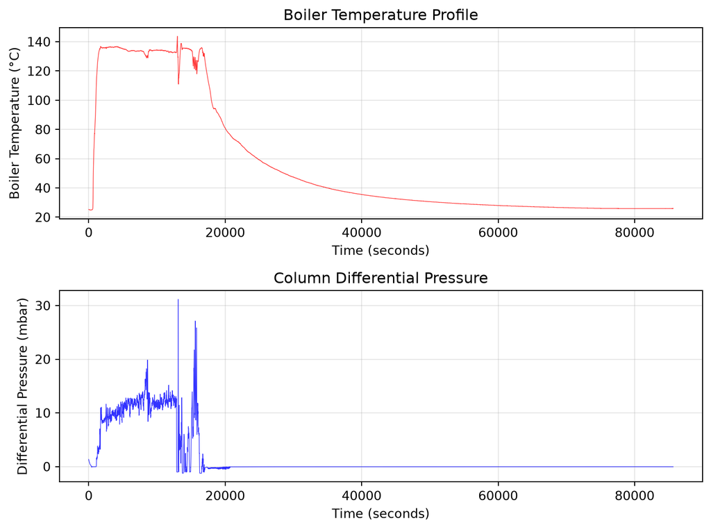

From the plot above, the meaningful operation occurs in roughly the first 20% of the record. Create a filtered DataFrame called `df_stable` that keeps only this window, using a boolean condition on the `Time,s` column. We will use `df_stable` for all of the analysis that follows.

**Tip**

You can filter a DataFrame by passing it a condition: `df[(df['Time,s'] >= start) & (df['Time,s'] <= end)]`.

**Callout-answer**Answer**

```
plot_operating_region.py
```

```python
def plot_operating_region(distillation):

    """
    Plot selected process variables as a function of time.

    Parameters
    ----------
    df : pd.DataFrame
        A DataFrame containing time-series process data.

    Returns
    -------
    None
        Displays plots of selected process variables to support
        exploratory analysis and process monitoring.
    """
    # Create a figure with two vertically stacked subplots
    fig, axes = plt.subplots(2, 1, figsize=(8, 6))

    # Plot boiler temperature against time
    axes[0].plot(distillation['Time,s'], distillation['Boiler_Temperature'],
                linewidth=0.5, alpha=0.8, color='red')
    axes[0].set_xlabel('Time (seconds)')
    axes[0].set_ylabel('Boiler Temperature (°C)')
    axes[0].set_title('Boiler Temperature Profile')
    axes[0].grid(True, alpha=0.3)

    # Plot column differential pressure against time
    axes[1].plot(distillation['Time,s'], distillation['Column_Differential_Pressure'],
                linewidth=0.5, alpha=0.8, color='blue')
    axes[1].set_xlabel('Time (seconds)')
    axes[1].set_ylabel('Differential Pressure (mbar)')
    axes[1].set_title('Column Differential Pressure')
    axes[1].grid(True, alpha=0.3)

    plt.tight_layout()
    plt.show()

plot_operating_region(distillation_cleaned)
```

Output

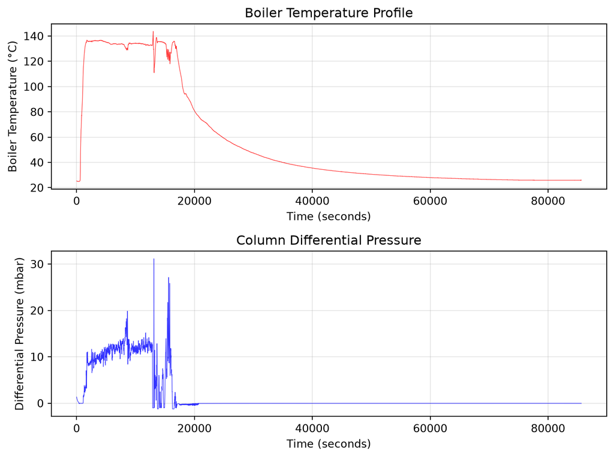

### Task 6 : Visualising distributions

A **histogram** shows how the values of a variable are distributed. Plotting a histogram for every variable at once is a quick way to spot the character of each signal. Write a function `plot_distributions` that uses `.hist()` to plot a histogram for every column in `df_stable`. Use 30 bins, a figure size of (20, 16), and set the edge colour to black and alpha to 0.7 for better visibility.

```
plot_distributions.py
```

```python
def plot_distributions(df, bins=30, figsize=(20, 16)):
    """
    Plot histograms for every column in the DataFrame.

    Parameters
    ----------
    df : pd.DataFrame
        The DataFrame containing the data to plot.
    bins : int, optional
        The number of bins for the histograms (default is 30).
    figsize : tuple, optional
        The size of the figure (default is (20, 16)).

    Returns
    -------
    None
        Displays the histograms.
    """
```

plot_distributions(df_stable)

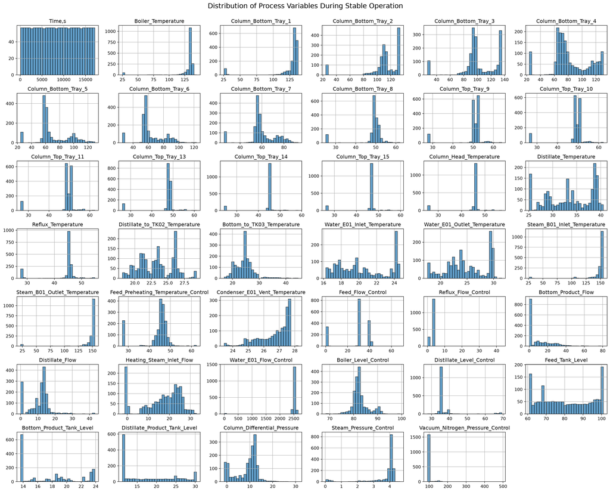

**Callout-answer**Answer**

```
plot_distributions.py
```

```python
def plot_distributions(df, bins=30, figsize=(20, 16)):
    """
    Plot histograms for every column in the DataFrame.

    Parameters
    ----------
    df : pd.DataFrame
        The DataFrame containing the data to plot.
    bins : int, optional
        The number of bins for the histograms (default is 30).
    figsize : tuple, optional
        The size of the figure (default is (20, 16)).

    Returns
    -------
    None
        Displays the histograms.
    """
    df.hist(bins=bins, figsize=figsize, edgecolor='black', alpha=0.7)
    plt.suptitle('Distribution of Process Variables During Stable Operation', fontsize=16, y=1.0)
    plt.tight_layout()
    plt.show()

plot_distributions(df_stable)
```

Output

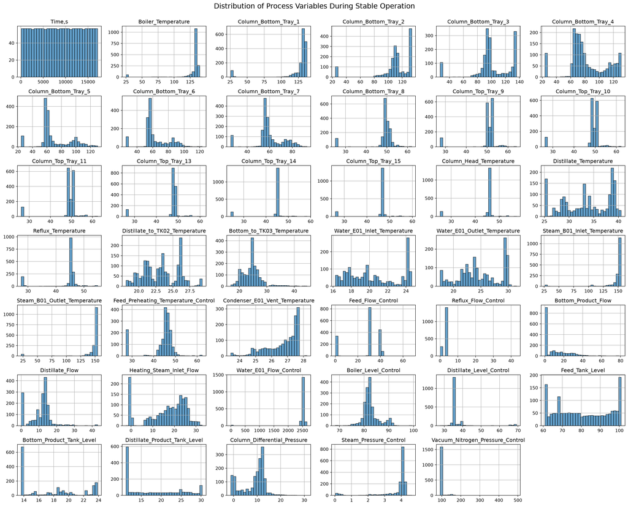

**NoteWhat to look for in a distribution**

- **Bell-shaped (approximately normal):** the variable fluctuates randomly around a stable operating point or setpoint.
- **Skewed:** the variable spends more time at one end of its range, often due to physical limits, process constraints, infrequent disturbances, or on/off operation.
- **Multi-modal (multiple peaks):** the process is operating in multiple states, operating regions, or control modes.
- **Narrow distribution:** low variability and generally tight process control.
- **Wide distribution:** high variability, suggesting disturbances, changing operating conditions, or less effective control.

Inspect each histogram and discuss your observations with your peers.

### Task 7 : Visualising process variables over time

Histograms tell us *how often* values occur, but not *when*. A **time series** plot reveals process dynamics, control performance, and disturbances. Write a function `plot_time_series` that plots the following four key variables against `Time,s`, one subplot each, and adds a dashed line showing each variable’s mean:

```python
key_variables = [
    'Boiler_Temperature',
    'Column_Differential_Pressure',
    'Boiler_Level_Control',
    'Feed_Flow_Control',
]
```

```
plot_time_series.py
```

```python
def plot_time_series(df, key_variables):
    """
    Plot selected process variables as time-series data.

    Parameters
    ----------
    df : pd.DataFrame
        A DataFrame containing time-series process measurements.

    key_variables : list
        A list of column names representing the process variables
        to be plotted.

    Returns
    -------
    None
        Displays time-series plots for the selected variables,
        including the mean value of each variable as a reference line.
    """
```

Your plot should look like the figure below.

plot_time_series(df_stable, key_variables)

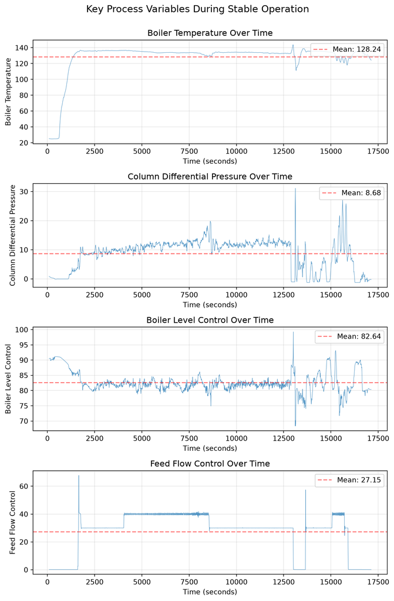

**Callout-answer**Answer**

```
plot_time_series.py
```

```python
def plot_time_series(df, key_variables):
    """
    Plot selected process variables as time-series data.

    Parameters
    ----------
    df : pd.DataFrame
        A DataFrame containing time-series process measurements.

    key_variables : list
        A list of column names representing the process variables
        to be plotted.

    Returns
    -------
    None
        Displays time-series plots for the selected variables,
        including the mean value of each variable as a reference line.
    """

    # Create one subplot for each selected variable
    fig, axes = plt.subplots(len(key_variables), 1, figsize=(8, 3 * len(key_variables)))

    for i, var in enumerate(key_variables):
        axes[i].plot(df['Time,s'], df[var], linewidth=0.5, alpha=0.8)
        axes[i].set_xlabel('Time (seconds)')
        axes[i].set_ylabel(var.replace('_', ' '))
        axes[i].set_title(f'{var.replace("_", " ")} Over Time')
        axes[i].grid(True, alpha=0.3)

        # Calculate and display the mean value
        mean_val = df[var].mean()
        axes[i].axhline(y=mean_val, color='r', linestyle='--', alpha=0.5,
                        label=f'Mean: {mean_val:.2f}')
        axes[i].legend(loc='upper right')

    plt.suptitle('Key Process Variables During Stable Operation', fontsize=14, y=1.0)
    plt.tight_layout()
    plt.show()

plot_time_series(df_stable, key_variables)
```

Output

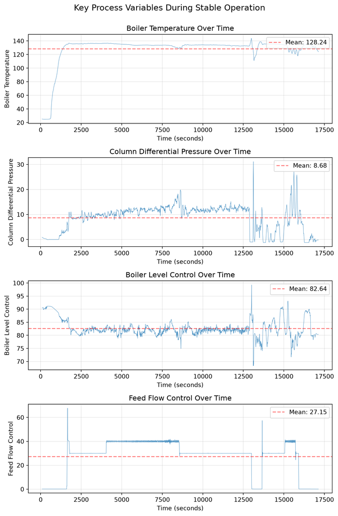

### Task 8 : Exploring relationships between variables

Write a function `plot_scatter_relationships` to produce a 2×2 grid of scatter plots for the following variable pairs, and annotate each subplot with the correlation coefficient (`df_stable[x].corr(df_stable[y])`):

```python
variable_pairs = [
    ('Boiler_Temperature', 'Boiler_Level_Control', 'Temperature vs Level Control'),
    ('Column_Differential_Pressure', 'Boiler_Level_Control', 'Pressure Drop vs Level'),
    ('Feed_Flow_Control', 'Distillate_Flow', 'Feed vs Distillate Flow'),
    ('Boiler_Temperature', 'Column_Bottom_Tray_1', 'Boiler vs Bottom Tray Temperature'),
]
```

```
plot_scatter_relationships.py
```

```python
def plot_scatter_relationships(df, variable_pairs):
    """
    Create scatter plots to visualize relationships between selected variables.

    Parameters
    ----------
    df : pd.DataFrame
        A DataFrame containing the variables to be analyzed.

    variable_pairs : list of tuples
        A list of (x_variable, y_variable, title) tuples specifying
        the variable pairs to plot and the title for each subplot.

    Returns
    -------
    None
        Displays scatter plots for the selected variable pairs and
        annotates each plot with the corresponding correlation coefficient.
    """
```

Your plot should look like the figure below.

plot_scatter_relationships(df_stable, variable_pairs)

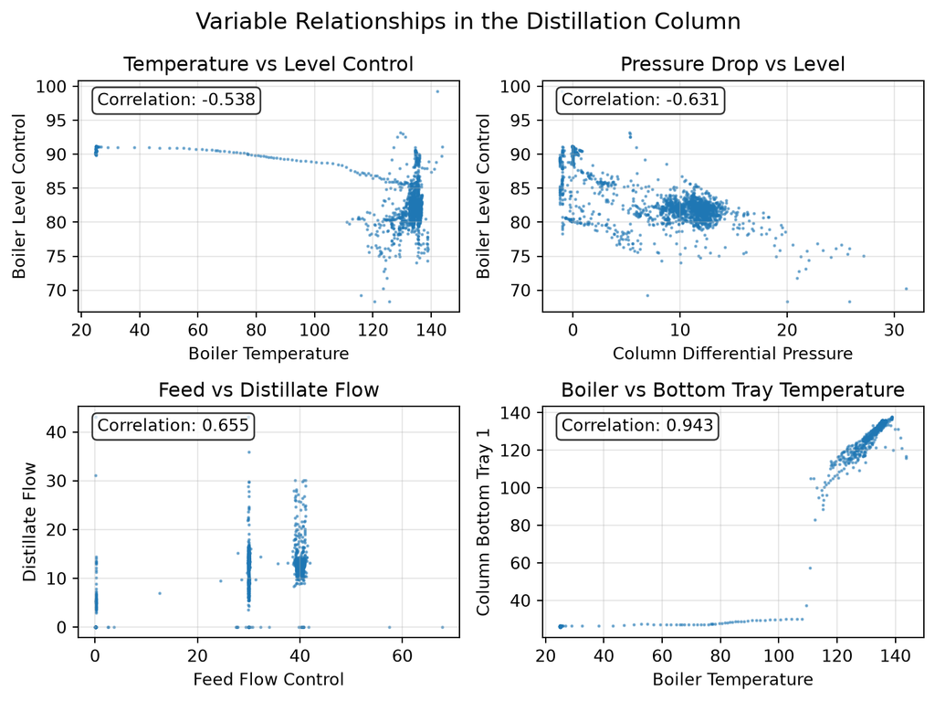

**NoteScatter plot interpretation**

- **Linear pattern:** a direct relationship (positive or negative)
- **Curved pattern:** a non-linear relationship
- **Cloud / no pattern:** the variables are independent
- **Clusters or distinct lines:** different operating modes

Notice that *Feed Flow vs Distillate Flow* shows several distinct straight lines. These often indicate that an operator adjusted the feed rate in steps, producing several discrete operating regimes.

**Callout-answer**Answer**

```
plot_scatter_relationships.py
```

```python
def plot_scatter_relationships(distillation, variable_pairs):
    """
    Create scatter plots to visualize relationships between selected variables.

    Parameters
    ----------
    distillation : pd.DataFrame
        A DataFrame containing the variables to be analyzed.

    variable_pairs : list of tuples
        A list of (x_variable, y_variable, title) tuples specifying
        the variable pairs to plot and the title for each subplot.

    Returns
    -------
    None
        Displays scatter plots for the selected variable pairs and
        annotates each plot with the corresponding correlation coefficient.
    """

    fig, axes = plt.subplots(2, 2, figsize=(8, 6))
    axes = axes.flatten()

    for i, (x_var, y_var, title) in enumerate(variable_pairs):
        axes[i].scatter(distillation[x_var], distillation[y_var], alpha=0.5, s=1)
        axes[i].set_xlabel(x_var.replace('_', ' '))
        axes[i].set_ylabel(y_var.replace('_', ' '))
        axes[i].set_title(title)
        axes[i].grid(True, alpha=0.3)

        corr = distillation[x_var].corr(distillation[y_var])
        axes[i].text(0.05, 0.95, f'Correlation: {corr:.3f}',
                     transform=axes[i].transAxes,
                     bbox=dict(boxstyle='round', facecolor='white', alpha=0.8),
                     verticalalignment='top')

    plt.suptitle('Variable Relationships in the Distillation Column', fontsize=14)
    plt.tight_layout()
    plt.show()

plot_scatter_relationships(df_stable, variable_pairs)
```

Output

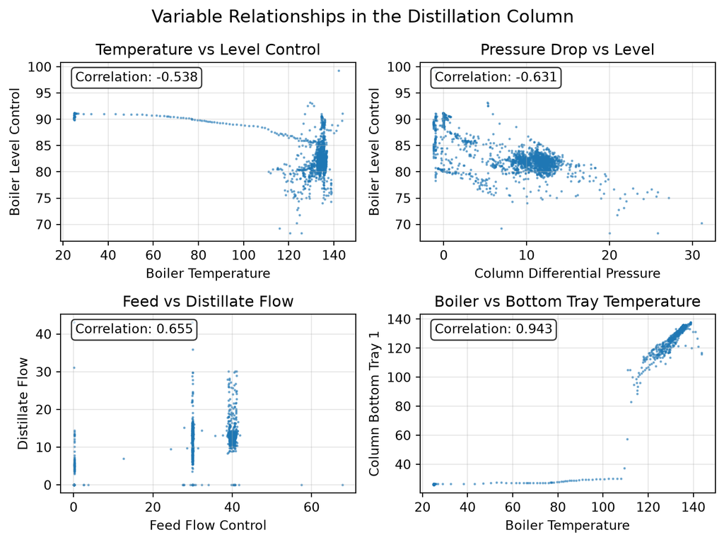

Each scatter plot above also shows the **correlation coefficient**, which quantifies the strength and direction of the linear relationship between the two variables. For now, treat it as a measure of how strongly the variables are related. In the next task, you will learn how these correlation coefficients are calculated and how they can be extended to analyse relationships between all variables in the dataset at once.

### Task 9 : Correlation analysis

Examining variable pairs one at a time is slow. The `.corr()` method computes the **correlation between every pair of variables at once**, returning a correlation matrix. You can visualise this matrix as a **heatmap** (with `seaborn`) lets you see the whole web of relationships at a glance. Write a function `plot_correlation_heatmap` that compute this correlation matrix and plots it as a heatmap. You should use the “coolwarm” colour map.

```
plot_correlation_heatmap.py
```

```python
def plot_correlation_heatmap(df):
    """
    Visualize correlations between variables using a heatmap.

    Parameters
    ----------
    df : pd.DataFrame
        A DataFrame containing the variables to be analyzed.

    Returns
    -------
    None
        Displays a heatmap of the correlation matrix, providing
        a visual summary of the strength and direction of linear
        relationships between variables.
    """
```

**NoteInterpreting the correlation coefficient**

The correlation coefficient ($r$) quantifies the strength and direction of a linear relationship:

| Correlation coefficient | Interpretation |
| --- | --- |
| r ≈ +1 | Very strong positive correlation (both variables increase together). |
| r ≈ +0.7 to +0.9 | Strong positive correlation. |
| r ≈ +0.3 to +0.7 | Moderate positive correlation. |
| r ≈ 0 | Little or no linear relationship. |
| r ≈ -0.3 to -0.7 | Moderate negative correlation. |
| r ≈ -0.7 to -0.9 | Strong negative correlation. |
| r ≈ -1 | Very strong negative correlation (one variable increases as the other decreases). |

Your heatmap should look like the figure below.

plot_correlation_heatmap(df_stable)

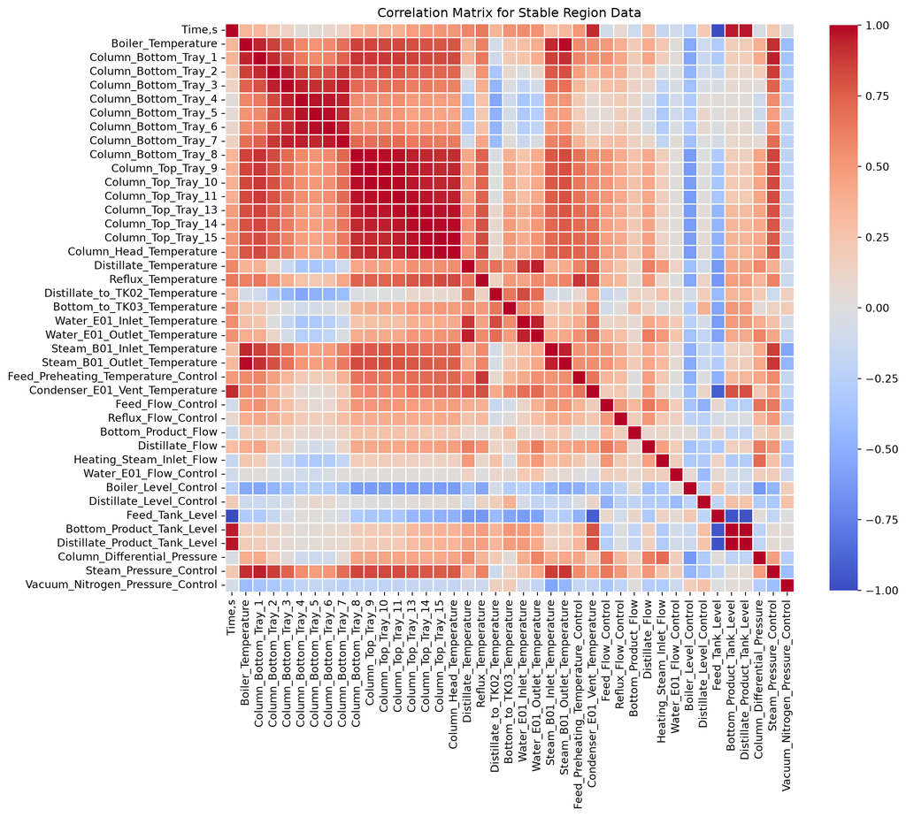

**Callout-answer**Answer**

```
plot_correlation_heatmap.py
```

```python
def plot_correlation_heatmap(distillation):
    """
    Visualize correlations between variables using a heatmap.

    Parameters
    ----------
    distillation : pd.DataFrame
        A DataFrame containing the variables to be analyzed.

    Returns
    -------
    None
        Displays a heatmap of the correlation matrix, providing
        a visual summary of the strength and direction of linear
        relationships between variables.
    """

    corr_matrix = distillation.corr()

    plt.figure(figsize=(12, 12))
    sns.heatmap(corr_matrix,
                cmap='coolwarm',
                vmin=-1, vmax=1,
                center=0,
                square=True,
                linewidths=0.5,
                cbar_kws={"shrink": 0.8},
                annot=False)   # set to True to print the correlation values
    plt.title('Correlation Matrix for Stable Region Data')
    plt.show()

plot_correlation_heatmap(df_stable)
```

Output

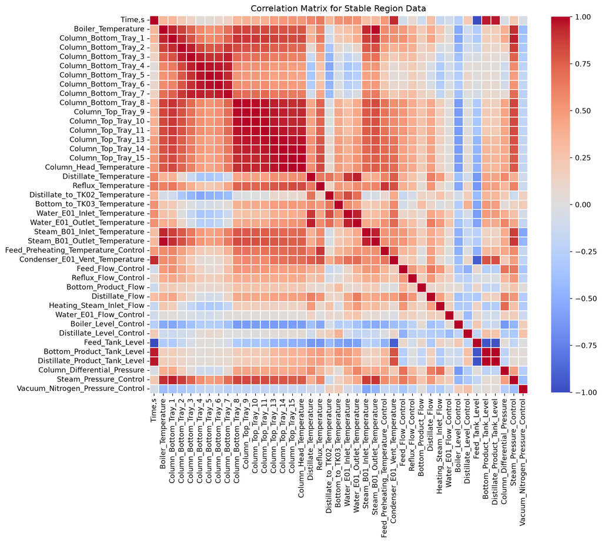

### Task 10 : Variance analysis

The coefficient of variance is an important metric for process stability. It is defined as the ratio of the standard deviation to the mean, expressed as a percentage. As you might suspect, a lower CV indicates a more variable with less variance. Write a function `plot_coefficient_of_variation` that computes the CV for each variable in `df_stable` and plots it as a horizontal bar chart.

```
plot_coefficient_of_variation.py
```

```python
def plot_coefficient_of_variation(df):
    """
    Compute and visualize the coefficient of variation for each variable.

    Parameters
    ----------
    df : pd.DataFrame
        A DataFrame containing the variables to be analyzed.

    Returns
    -------
    None
        Displays a bar chart of the coefficient of variation (CV)
        for each variable, providing a measure of relative variability
        and process stability.
    """
```

Your plot should look like the figure below.

plot_coefficient_of_variation(df_stable)

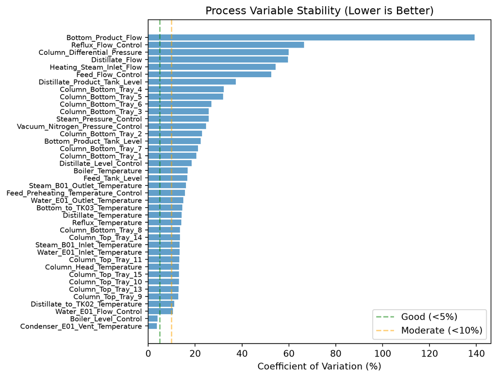

**Callout-answer**Answer**

```
plot_coefficient_of_variation.py
```

```python
def plot_coefficient_of_variation(distillation):
    """
    Compute and visualize the coefficient of variation for each variable.

    Parameters
    ----------
    distillation : pd.DataFrame
        A DataFrame containing the variables to be analyzed.

    Returns
    -------
    None
        Displays a bar chart of the coefficient of variation (CV)
        for each variable, providing a measure of relative variability
        and process stability.
    """
    cv_analysis = pd.DataFrame({
        'Variable': distillation.columns,
        'Mean': distillation.mean(),
        'Std_Dev': distillation.std(),
        'CV_%': (distillation.std() / distillation.mean() * 100).abs(),
    }).sort_values('CV_%', ascending=True)

    # Visualise the stability of every variable
    plot_data = cv_analysis[cv_analysis['Variable'] != 'Time,s']

    fig, ax = plt.subplots(figsize=(8, 6))
    ax.barh(range(len(plot_data)), plot_data['CV_%'], alpha=0.7)
    ax.set_yticks(range(len(plot_data)))
    ax.set_yticklabels(plot_data['Variable'], fontsize=8)
    ax.set_xlabel('Coefficient of Variation (%)')
    ax.set_title('Process Variable Stability (Lower is Better)')
    ax.axvline(x=5, color='green', linestyle='--', alpha=0.5, label='Good (<5%)')
    ax.axvline(x=10, color='orange', linestyle='--', alpha=0.5, label='Moderate (<10%)')
    ax.legend()
    plt.tight_layout()
    plt.show()

plot_coefficient_of_variation(df_stable)
```

Output

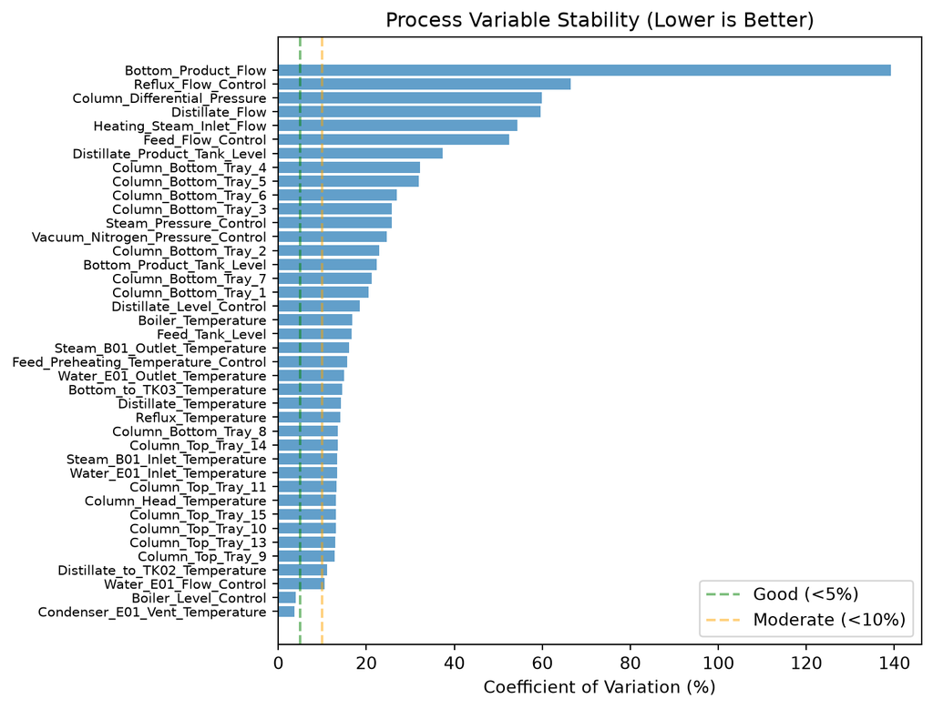

### Task 11 : Joint distribution analysis

For a final, more advanced view, write the function `plot_joint_distribution` to create a **joint plot** combines a scatter/density plot of two variables with their individual distributions shown on the margins. This is a powerful way to understand how two variables co-vary, which matters when designing a control strategy. Use `seaborn`’s `JointGrid` to plot `Boiler_Level_Control` against `Heating_Steam_Inlet_Flow`, with a filled KDE in the centre and histograms on the margins.

```
plot_joint_distribution.py
```

```python
def plot_joint_distribution(df, var1, var2):
    """
    Visualize the joint distribution of two variables.

    Parameters
    ----------
    df : pd.DataFrame
        A DataFrame containing the variables to be analyzed.

    var1 : str
        The name of the variable plotted on the x-axis.

    var2 : str
        The name of the variable plotted on the y-axis.

    Returns
    -------
    None
        Displays a joint distribution plot consisting of:
        - A kernel density estimate (KDE) of the relationship
          between the two variables
        - Marginal histograms with density estimates
        - The Pearson correlation coefficient between the variables
    """
```

Your plot should look like the figure below.

plot_joint_distribution(df_stable, 'Boiler_Level_Control', 'Heating_Steam_Inlet_Flow')

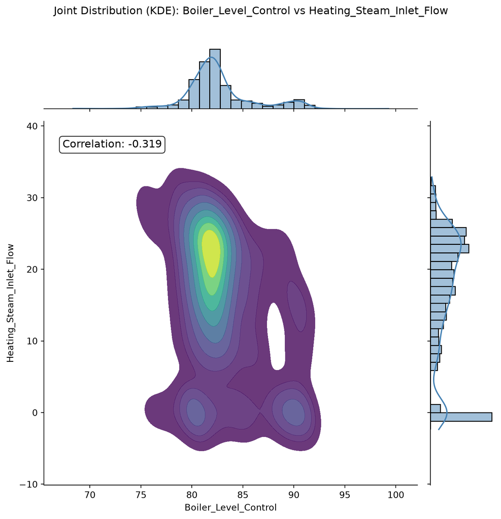

**Callout-answer**Answer**

```
plot_joint_distribution.py
```

```python
def plot_joint_distribution(distillation, var1, var2):
    """
    Visualize the joint distribution of two variables.

    Parameters
    ----------
    distillation : pd.DataFrame
        A DataFrame containing the variables to be analyzed.

    var1 : str
        The name of the variable plotted on the x-axis.

    var2 : str
        The name of the variable plotted on the y-axis.

    Returns
    -------
    None
        Displays a joint distribution plot consisting of:
        - A kernel density estimate (KDE) of the relationship
          between the two variables
        - Marginal histograms with density estimates
        - The Pearson correlation coefficient between the variables
    """
    g = sns.JointGrid(data=distillation, x=var1, y=var2, height=8)
    g.plot_joint(sns.kdeplot, fill=True, cmap='viridis', alpha=0.8)
    g.plot_marginals(sns.histplot, bins=30, kde=True, color='steelblue')

    corr = distillation[var1].corr(distillation[var2])
    g.ax_joint.text(0.05, 0.95, f'Correlation: {corr:.3f}',
                    transform=g.ax_joint.transAxes,
                    bbox=dict(boxstyle='round', facecolor='white', alpha=0.8),
                    verticalalignment='top', fontsize=12)
    plt.suptitle(f'Joint Distribution (KDE): {var1} vs {var2}', y=1.02)
    plt.tight_layout()
    plt.show()

plot_joint_distribution(df_stable, 'Boiler_Level_Control', 'Heating_Steam_Inlet_Flow')
```

Output

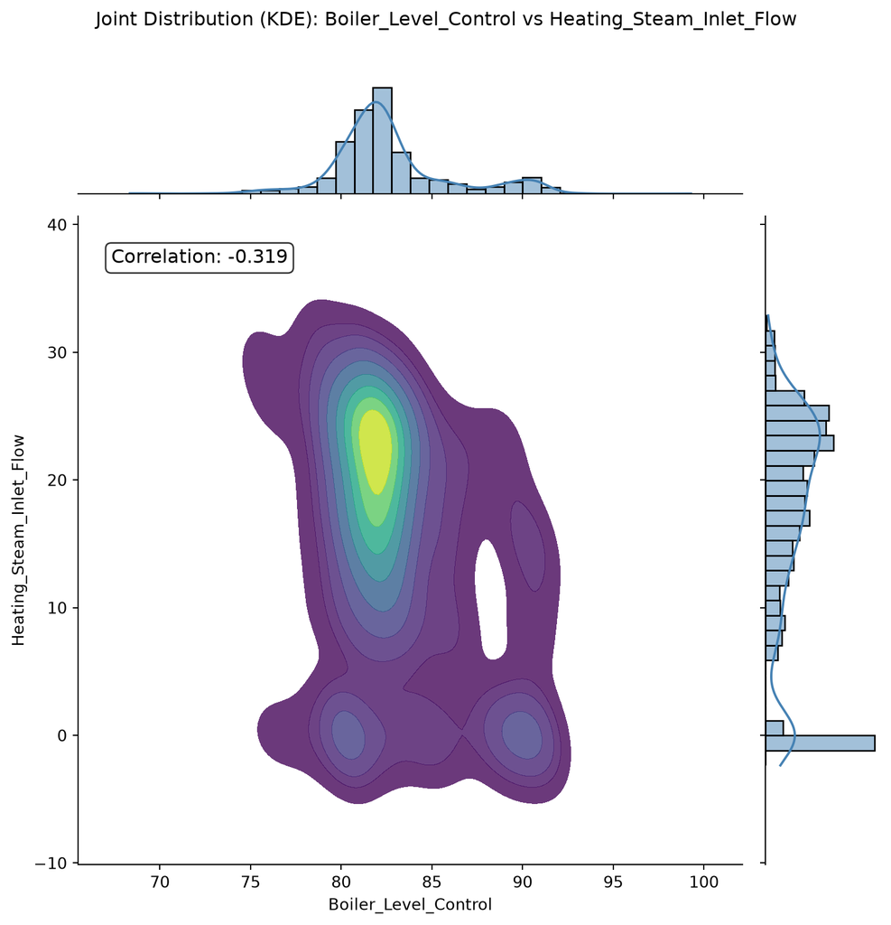

## Additional Resources

For further learning:

- [Pandas documentation](https://pandas.pydata.org/docs/)
- [Matplotlib gallery](https://matplotlib.org/stable/gallery/index.html)
- [Seaborn tutorial](https://seaborn.pydata.org/tutorial.html)
- [Scientific Python lectures](https://lectures.scientific-python.org/index.html)